# WB-XAI-2 Praca domowa 1

Janus Dawid

25 03 2021

## Wczytanie danych

```r
blood <- read.csv("D:/Studia/Projekty/R-projekty/blood.csv",
                   header = TRUE)

head(blood)
```

```
##   V1 V2    V3 V4 Class
## 1  2 50 12500 98     2
## 2  0 13  3250 28     2
## 3  1 16  4000 35     2
## 4  2 20  5000 45     2
## 5  1 24  6000 77     1
## 6  4  4  1000  4     1
```

## Informacje o danych

- V1: Recency - months since last donation
- V2: Frequency - total number of donation
- V3: Monetary - total blood donated in c.c.
- V4: Time - months since first donation)
- Class: The target attribute is a binary variable representing whether he/she donated blood in March 2007 (2 stands for donating blood; 1 stands for not donating blood).

## Zmiana nazw kolumn

```r
names(blood) <- c("Recency", "Frequency", "Monetary", "Time", "Class")

blood<-blood %>% mutate(Class=as.integer(Class-1))


head(blood)
```

```
##   Recency Frequency Monetary Time Class
## 1       2        50    12500   98     1
## 2       0        13     3250   28     1
## 3       1        16     4000   35     1
## 4       2        20     5000   45     1
## 5       1        24     6000   77     0
## 6       4         4     1000    4     0
```

## Tworzenie modelu

```r
classif_task <- makeClassifTask(data = blood, target = "Class")
classif_lrn <- makeLearner("classif.ranger", predict.type = "prob")
model_mlr <- train(classif_lrn, classif_task)
```

## Utworzenie explainera

```r
explainer <- explain(model = model_mlr,
                     data = blood[,-5],
                     y = blood[,5])
```

```
## Preparation of a new explainer is initiated
##   -> model label       :  WrappedModel  (  default  )
##   -> data              :  748  rows  4  cols
##   -> target variable   :  748  values
##   -> predict function  :  yhat.WrappedModel  will be used (  default  )
##   -> predicted values  :  numerical, min =  0.004254042 , mean =  0.2390857 , max =  0.9129708
##   -> model_info        :  package mlr , ver. 2.19.0 , task classification (  default  )
##   -> residual function :  difference between y and yhat (  default  )
##   -> residuals         :  numerical, min =  -0.729527 , mean =  -0.001117787 , max =  0.9381954
##   A new explainer has been created!
```

## Wyświetlenie jednej obserwacji

```r
prep  <-predict(model_mlr, newdata = blood[1,])$data$prob.1
prep
```

```
## [1] 0.7645214
```

```r
blood[1,5]
```

```
## [1] 1
```

## Dekompozycja lime dla kilku obserwacji w zbiorze

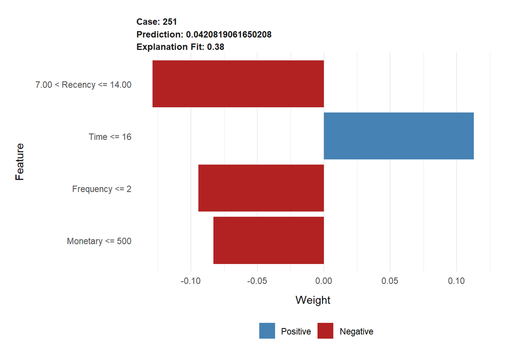

```r
lime_1 <- predict_surrogate(
  explainer=explainer,
  new_observation=blood[251,-5],
  n_features=4,
  n_permutations=1000,
  type='lime')
plot(lime_1)
```

```r
blood[251,]
```

```
##     Recency Frequency Monetary Time Class
## 251      11         2      500   11     0
```

W przypadku obserwacji numer 251 metoda wskazała pozytywny wpływ zmiennej *Time*, natomiast negatywny w przypadku pozostłych zmiennych. Model z bardzo dużym prawdopodobieństwem wskazał poprawną predykcje.

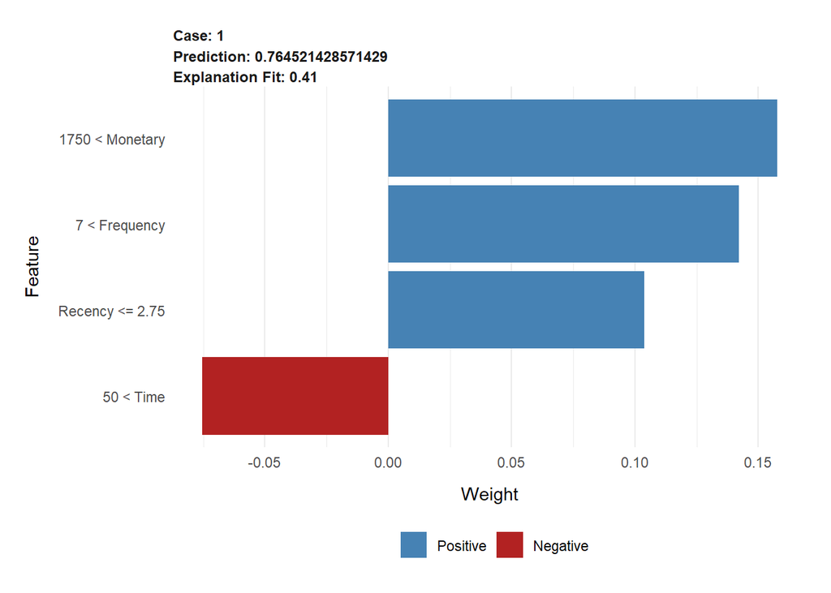

```r
lime_2 <- predict_surrogate(
  explainer=explainer,
  new_observation=blood[1,-5],
  n_features=4,
  n_permutations=1000,
  type='lime')
plot(lime_2)
```

```r
blood[1,]
```

```
##   Recency Frequency Monetary Time Class
## 1       2        50    12500   98     1
```

W powyższej obserwacji sytuacja jest odwrotna do poprzedniej. Wszystkie zmienne oprócz *Time* mają pozytywny wpływ na predykcje.

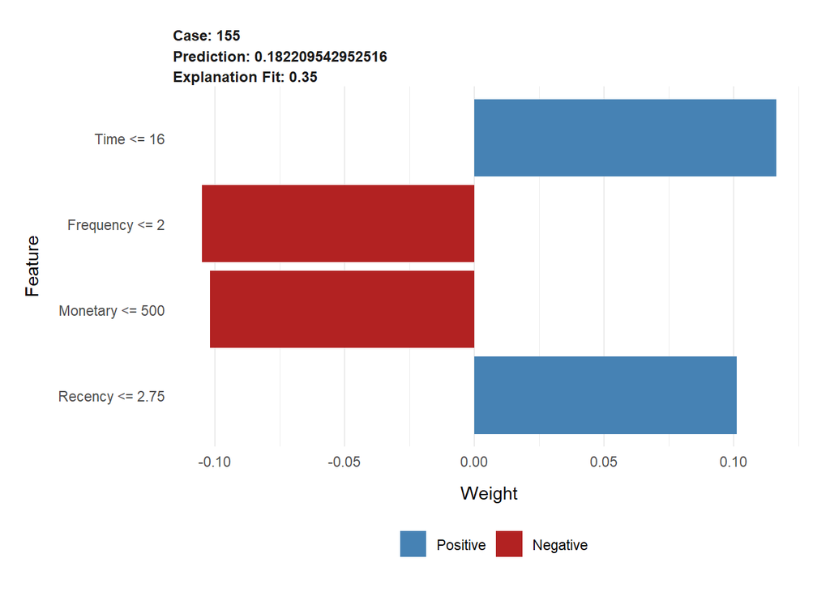

```r
lime_3 <- predict_surrogate(
  explainer=explainer,
  new_observation=blood[155,-5],
  n_features=4,
  n_permutations=1000,
  type='lime')
plot(lime_3)
```

```r
blood[155,]
```

```
##     Recency Frequency Monetary Time Class
## 155       2         1      250    2     0
```

Dla obserwacji 155 metoda Lime wskazała pozytywny wpływ zmiennej *Time* oraz *Recency* natomiast negatywny, prawie identyczny *Frequency* oraz *Monetary*, co nie jest zaskoczeniem, gdyż z poprzedniej pracy domowej wiemy, że te zmienne są ze sobą mocno skorelowane.

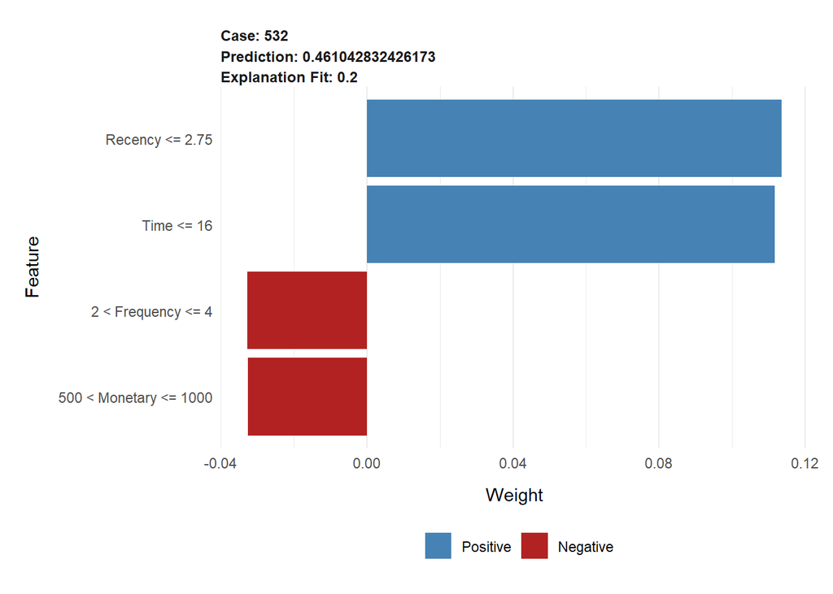

```r
lime_4 <- predict_surrogate(
  explainer=explainer,
  new_observation=blood[532,-5],
  n_features=4,
  n_permutations=1000,
  type='lime')
plot(lime_4)
```

```r
blood[532,]
```

```
##     Recency Frequency Monetary Time Class
## 532       2         4     1000   14     1
```

W podanym przypadku sytuacja jest podobna do poprzedniej obserwacji. Rożnica polega na mniejszym wpływie zmiennych *negatywnych*.

## Porównanie BreakDown z Lime

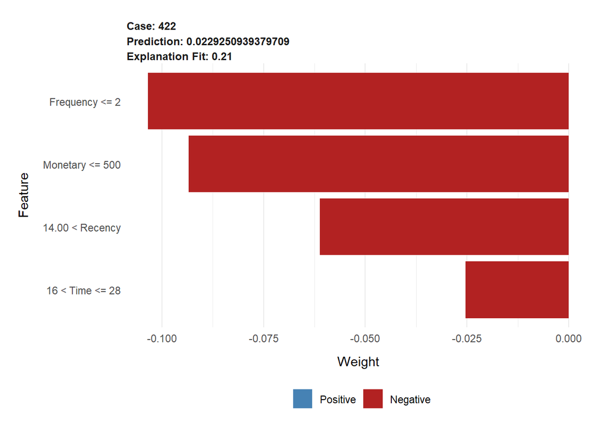

```r
lime_5 <- predict_surrogate(
  explainer=explainer,
  new_observation=blood[422,-5],
  n_features=4,
  n_permutations=1000,
  type='lime')
plot(lime_5)
```

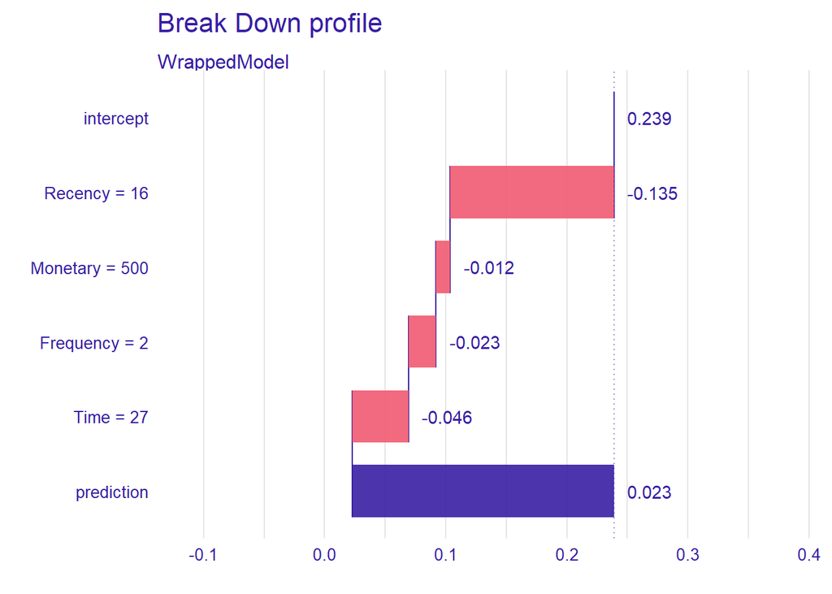

```r
bd <- predict_parts(explainer, new_observation=blood[422,-5])
plot(bd)
```

```r
blood[422,]
```

```
##     Recency Frequency Monetary Time Class
## 422      16         2      500   27     0
```

Dla powyższej obserwacji zarówno metoda Lime jak i BreakDown wskazuje wszystkie zmienne jako negatywne. W przypadku BreakDown najbardziej wpływową zmienną jest *Recency*, natomiast z wykresu Lime można odczytać, że zmienne mają bardziej przybliżony wpływ.

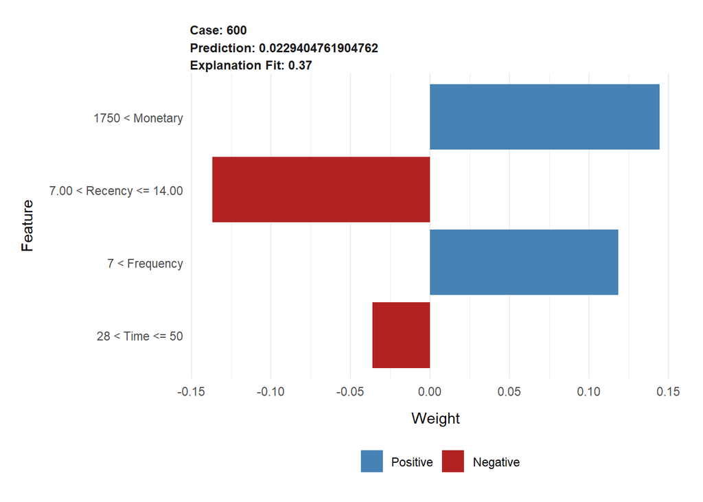

```r
lime_6 <- predict_surrogate(
  explainer=explainer,
  new_observation=blood[600,-5],
  n_features=4,
  n_permutations=1000,
  type='lime')
plot(lime_6)
```

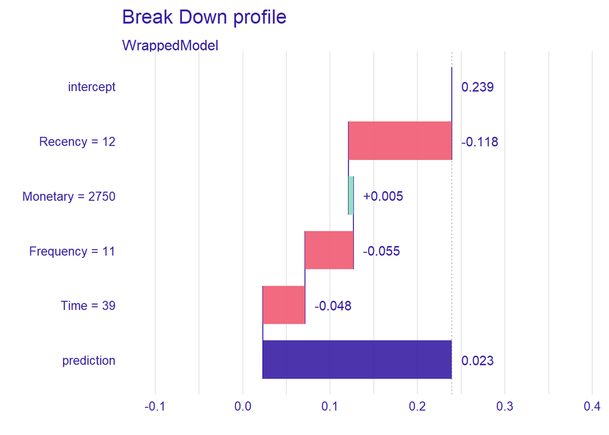

```r
bd <- predict_parts(explainer, new_observation=blood[600,-5])
plot(bd)
```

```r
blood[600,]
```

```
##     Recency Frequency Monetary Time Class
## 600      12        11     2750   39     0
```

Dla obserwacji 600 metoda BreakDown wskazuje tylko jedną zmienną majać pozytwny wpływ, jest nią *Monetary*. Co ciekawe zmienne *Monetary* oraz *Frequency* mają przeciwny wpływ mimo, że sa bardzo mocno ze sobą skorelowane. Natomiast z metody Lime można zauważyc tą zależność. Obie zmienne, jako jedyne, mają dodatni wpływ na predykcje.